# Variable Selection in High-Dimensional Settings

Nicole Gemelli, Federica Romano, Davide Tortorella

2025-11-28

In this lecture, we address the problem of variable selection in **High-Dimensional Scenario** ($p \gg n$), where the number of predictors exceeds the number of observations. Standard OLS regression fails in this setting due to the singularity of the matrix $X^TX$.

While methods like **LASSO** provide a way to select variables by shrinking coefficients to zero, they do not inherently provide p-values or statistical significance for the selected variables. To overcome this, we implement different techniques that combine variable selection and inference through different data splitting approaches.

# 1 High-dimensional inference

Considering the Gaussian linear regression model as

$$y \sim N_n\left(\mathbf{1}_n \beta_0 + X \beta, \sigma^2 I_n \right)$$

where:

- $X$ is an $n \times p$ design matrix,
- $\beta$ is a $p \times 1$ vector of regression coefficients,
- $\beta_0$ is the intercept,
- $\sigma^2$ is the noise variance.

**Focus: High dimensional setting**

When the number of parameters is greater than the sample size, $p \geq n$, we are not able to use the ordinary least squares estimator because the matrix $X^TX$ is singular ($det=0$). The consequences are the following:

- The OLS estimator $\hat{\beta}_{OLS}$ isn’t unique.
- We can’t directly use standard inferential tools as confidence intervals and p-values.
- Regularization or sparsity assumptions are required.

The *goal* here is to make inference on individual parameters, under structural assumptions such as the sparsity of $\beta$.

## 1.1 The Stars of High-Dimensional Regression

### 1.1.1 Sparsity and support set

A fundamental assumption in high-dimensional regression is that the $\beta_k$ coefficients are **sparse**, this means that most of the values are zero or very close to zero, and only a few are significant. To formalize this, we can use a support set:

$$S = \{ j \in \{1, \dots, p\} : \beta_j \ne 0 \},$$

S contains the indices of the variables that really matter for the analyses. The cardinality is $s = |S|$, it corresponds to the “active” variables.

The complement is the **null set**:

$$N = \{ j \in \{1, \dots, p\} : \beta_j = 0 \}.$$
It can be considered as a set of “noise” variables, which are irrelevant for the analyses.

As the support set is unknown we must try to estimate it from the data,

$\widehat{S} \subseteq \{1, \dots, p\}$.

We can use methods like **LASSO**, which shrinks small coefficients to zero. After fitting, the nonzero coefficients defines $\widehat S$. We would like $\widehat S$ to fit the support $S$ as much as possible.

### 1.1.2 Type I and type II errors

Given the estimated $\widehat S$, we can compute:

- **False positive** or **type I error**: $|\widehat{S} \cap N|$

The probability of committing a type I error (incorrectly rejecting a true null hypothesis) is indicated with $\alpha$. For example, to consider guilty an innocent person.

- **False negative** or **type II error**: $|S \setminus \widehat{S}|$

The probability of committing a type II error (incorrectly not rejecting a false null hypothesis) is indicated with $\beta$. For example, to not consider guilty an actual guilty person.

Balancing these errors is central in high-dimensional inference.

### 1.1.3 Error rate

Estimating the support set can be risky because we may select irrelevant variables while leaving out the important ones. The following measures are used to formalize the Type I error in case of $p \geq n$.

The **False Discovery Proportion(FDP)** defined as:

$$FDP = \frac{|\widehat{S} \cap N|}{\widehat S}$$

It is the proportion of false positives among all the supposed relevant features.

**FamilyWise Error Rate(FWER)**:

$$FWER = P(FDP(\widehat S)>0)= P(|\widehat{S} \cap N| \neq 0)$$

It’s the probability of making at least one Type I error.

**False Discovery Rate(FDR)**:

$$FDR = E(FDP(\widehat S))$$

### 1.1.4 Simulated Framework

Let’s now analyse the performances of variable selection through LASSO, given a **simulated framework**.

```r
library(glmnet)

# define parameters
alpha <- 0.05
n <- 200
p <- 1000
s <- 10 # active covariates
beta <- c(rep(1,s),rep(0,p-s)) # true beta: (1,...,1,0,...,0)
rho <- 0
Sigma <- toeplitz(rho^(0:(p-1)))
SNR <- 2.5
sigma2 <- (t(beta) %*% Sigma %*% beta) / SNR

S <- which(beta != 0)
varType <- rep("N",p)
varType[S] <- "S" # a 1000-d vector, whose first s values are "S", the others "N"

set.seed(123)
# design matrix
X <- as.matrix(matrix(rnorm(n * p), n, p) %*% chol(Sigma) )
# true response y
y <- X %*% beta + rnorm(n,mean=0,sd=sqrt(sigma2))

fit <- cv.glmnet(X, y)
M_hat <- which(coef(fit, s=fit$lambda.1se)[-1] != 0)
table(varType[M_hat])

create_performance_table <- function(M_hat, beta_true) {

  S <- which(beta_true != 0)
  N <- which(beta_true == 0)

  abs_S <- length(S)  # |S|
  abs_N <- length(N)  # |N|

  size_hat <- length(M_hat) # |S^|

  type_I <- length(intersect(M_hat, N))

  type_II <- length(setdiff(S, M_hat))

  true_positives <- length(intersect(M_hat, S))

  if (size_hat > 0) {
    fdp <- type_I / size_hat
  } else {
    fdp <- 0
  }

  sensitivity <- true_positives / abs_S

  # df
  result_tab <- data.frame(
    "|S_hat|" = size_hat,     # |S^|
    "|N|" = abs_N,            # |N|
    "|S|" = abs_S,            # |S|
    "|Type_I|" = type_I,      # |S^ intersection N|
    "|Type_II|" = type_II,    # |S \ S^|
    "FDP" = round(fdp,3),                # FDP
    "Power" = sensitivity, # Power
    check.names = FALSE
  )

  return(result_tab)
}

final_table <- create_performance_table(M_hat, beta)
print(final_table, row.names = FALSE)
```

```
##
##  N  S
## 13 10
##  |S_hat| |N| |S| |Type_I| |Type_II|   FDP Power
##       23 990  10       13         0 0.565     1
```

 Starting with a setup of $p=1000$ total features and $s=10$ true active features, the model selected a total of 23 variables ($|\hat{S}|=23$). While the procedure achieved perfect power (Sensitivity = 1), successfully recovering all 10 true variables, it exhibited a high False Discovery Proportion (FDP = 0.565), including 13 false positives (Type I errors)

### 1.1.5 Error control

When performing variable selection in a high-dimensional space, we must be aware of two important issues:

1. Avoid type I error, it means that we should not include in the support set false positive variables;
2. Maximize power, we must include as many as the truly relevant variables as possible.

These two goals cannot both be perfectly achieved, for this reason we need to choose an error metric to control, and then try to achieve the highest possible power under that constraint.

The most common solution is to choose a value of $\alpha$ and require that the selected model satisfies on of the following two controls:

- FWER control:
  $$P(\widehat{S} \cap N \neq \emptyset) \le \alpha$$
  the probabily of incluining even one false positive must be very small.
- FDR control:
  $$\mathbb{E}\left[ \mathrm{FDP}(\widehat{S}) \right] \le \alpha$$
  averagely the probability of selecting a false positive should be low.

The first one is stricter because it wants to avoid any mistake, the second one allow false classification but it should be a very small percentage.

On the one hand we would like to keep under control the false positive rate, on the other we would like to maximize the correct classification rate. A way to do it is the **Average Power**:

$$\text{AvgPower}
= \frac{1}{|S|} \sum_{j \in S} P(j \in \widehat{S})$$

$\text{AvgPower} \in [0,1]$

It is the average probability of correctly selecting a truly relevant variable. If the value is high it means that we detect most of the real signals; if it is low we miss many true variables.

It’s important to highlight that there is an important trade-off between type I and type II error. If we tend to be strict with false positive, we will be very conservative in selecting variables. In case of lower power we allow more type II errors. Opposite to this allowing a bit more flexibility leads to less conservative choices and can select more true variables. Meaning that, higher power leads to fewer Type II errors.

This idea leads to the inequality:

$$\mathbb{E}\left[ \mathrm{FDP}(\widehat{S}) \right]
\le
P(\widehat{S} \cap N \neq \emptyset)$$

Controlling FWER controls FDR but not the contrary.

What does this mean?

- To guarantee no false positive, the procedure must be extremely cautious, rarely selecting variables unless the evidence is overwhelming.
- FDR-controlling methods accept that a small proportion of errors is tolerable, so they can be more aggressive and recover more signals. The flexibility of this method perfectly adapt with the high-dimensional regression, so it is preferred.

### 1.1.6 Simulated Framework

Let’s now replicate the previous example by repeating it 100 times, to better estimate the cited metrics.

```r
alpha <- 0.05
n <- 200
p <- 1000
s <- 10
beta <- c(rep(1,s), rep(0,p-s))
S <- which(beta != 0)
rho <- 0
Sigma <- toeplitz(rho^(0:(p-1)))
SNR <- 2.5
sigma2 <- (t(beta) %*% Sigma %*% beta) / SNR

# function for the single simulation
one_rep <- function() {
  X <- as.matrix(matrix(rnorm(n * p), n, p) %*% chol(Sigma))
  y <- X %*% beta + rnorm(n, mean=0, sd=sqrt(sigma2))

  fit <- cv.glmnet(X, y)
  M_hat <- which(coef(fit, s=fit$lambda.1se)[-1] != 0)

  true_pos <- length(intersect(M_hat, S))
  false_pos <- length(setdiff(M_hat, S))

  # metrics
  sensitivity <- true_pos / length(S) # Power
  fwer <- as.numeric(false_pos > 0) # Binary indicator {1,0}
  fdr <- ifelse(length(M_hat) > 0, false_pos / length(M_hat), 0)
  # this is actually the FDP, when averaging, I'll get FDR

  return(c(FWER=fwer, FDR=fdr, Power=sensitivity))
}
```

```r
set.seed(123)
B <- 100
res <- replicate(B, one_rep())

# results
FWER_est <- mean(res["FWER", ])
FDR_est  <- mean(res["FDR", ])
AvgPower <- mean(res["Power", ])

summary_table <- data.frame(
  Metrics = c("FWER", "FDR", "Average Power"),
  Value = c(FWER_est, FDR_est, AvgPower)
)
summary_table$Value <- round(summary_table$Value, 3)
print(summary_table, row.names = FALSE)
```

```
##        Metrics Value
##           FWER 0.990
##            FDR 0.543
##  Average Power 0.996
```

With a target $\alpha = 0.05$, the goal is to limit the probability of making even a single false discovery to 5%. However, in 99% of the simulations, the selected set $\hat{S}$ contained at least one false positive. In terms of strict error control, this result is catastrophic: it is virtually guaranteed (99%) that the model will include noise in every run.

While we aimed to accept only 5% false discoveries, the reality is that 54.3% of the selected variables are, on average, non-significant.

On the other hand, the model achieved near-perfect power, recovering 99.6% of the true signals ($S$). This reveals the strategy of the LASSO in this configuration: it behaves inclusively. It prioritizes not missing any true signal at the cost of including a substantial amount of noise.

Techniques like Data Splitting are necessary to “clean up” this 54% FDR and bring it back under control (< 5%). However, this filtering process will inevitably require sacrificing some of this near-perfect power.

# 2 First example: RiboFlavin

In this analysis, we utilize the *Riboflavin* dataset, which describes riboflavin (Vitamin B2) production of the Bacillus Subtilis bacterium. The dataset consists of $n=71$ observations and $p=4,088$ predictors, presenting a high-dimensional regression problem where $p \gg n$. The response variable ($y$) is the log-transformed riboflavin production rate. The predictors ($x$) represent the logarithm of the expression levels of 4,088 genes.

Our primary objective is to identify the specific genes that significantly influence production rates.

Let’s start by importing the dataset.

```r
library(hdi)
data(riboflavin)
```

```r
# response and design vectors
y <- riboflavin$y
X <- riboflavin$x
paste("Design Matrix dimensions:", dim(X)[1],"x", dim(X)[2] )
```

```
## [1] "Design Matrix dimensions: 71 x 4088"
```

- **y** is the response vector, representing riboflavin production for each strain.
- **X** is the design matrix containing all genes. The dimension of the matrix is *71(n) x 4088(p)*, this confirms that we are dealing with a high-dimensional case. We can show how the first 5 columns appear.

```r
n = nrow(X)
p = ncol(X)
X[1, 1:5] # example of the first 5 columns of the first row
```

```
##   AADK_at   AAPA_at   ABFA_at    ABH_at   ABNA_at
##  8.492404  8.111451  8.320842 10.287112  8.261279
```

We can check if there are some missing values, in that case we must think about strategies to “fill” them.

```
## [1] "Missing values in the design matrix: 0 and in the response variable: 0"
```

*Perfect situation*: we do not have missing data.

We are interested in the summary of both the variables and the design matrix, this may help us in better understanding the data we are dealing with.

```r
summary(y)
```

```
##    Min. 1st Qu.  Median    Mean 3rd Qu.    Max.
##  -9.966  -7.688  -6.948  -7.159  -6.449  -5.673
```

The response is logarithmically distributed, which is typical for biological measurements that span several orders of magnitude.

We must check the range of the design matrix, this would lead to discover the presence of extreme values or outliers.

```
## [1] "Design matrix values range between 3.323 and 14.39"
## [1] "Means summary:"
##    Min. 1st Qu.  Median    Mean 3rd Qu.    Max.
##   3.483   6.990   7.676   7.669   8.331  13.905
```

The summary of the means explains the distribution of these average expression levels. This provides an understanding of the baseline expression of each gene.

```
## [1] "Variances summary:"
##     Min.  1st Qu.   Median     Mean  3rd Qu.     Max.
## 0.009915 0.080388 0.131765 0.193266 0.235997 3.401312
```

It gives insight into which genes are highly variable and which are mostly constant. We should be aware that:

- Genes with very *low variance* are less likely to be informative predictors.
- *High variance* genes are more likely to correlate with riboflavin production.

## 2.1 EDA: Explorative Data Analyses

We would like to understand the distribution of the response variable. The *histogram* shows the distribution of the riboflavin across the 71 observations. While the *density curve* smooths the histogram to highlight the overall shape.

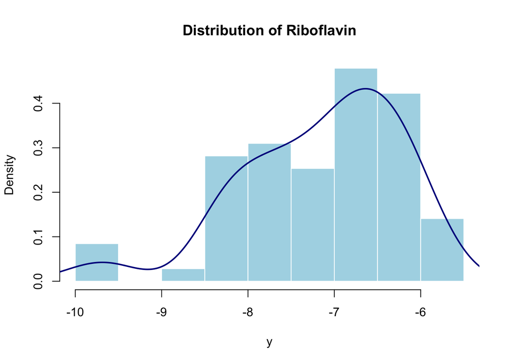

We would like to understand which genes are more correlated with the response.

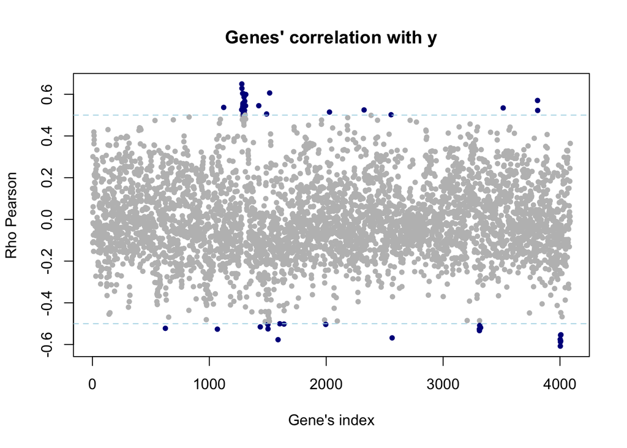

Most of the genes have a correlation $\in [-0.6,0.6]$. The blue points indicate the genes which are too correlated both positively and negatively. This plot is a preliminary **screening** to identify potentially informative predictors in a high-dimensional dataset. We must note that the genes with $\rho > 0.5$ are more probable to be prioritized in the LASSO penalization.

The distribution of the gene variance is really helpful to catch how many are almost constant versus the highly variable.

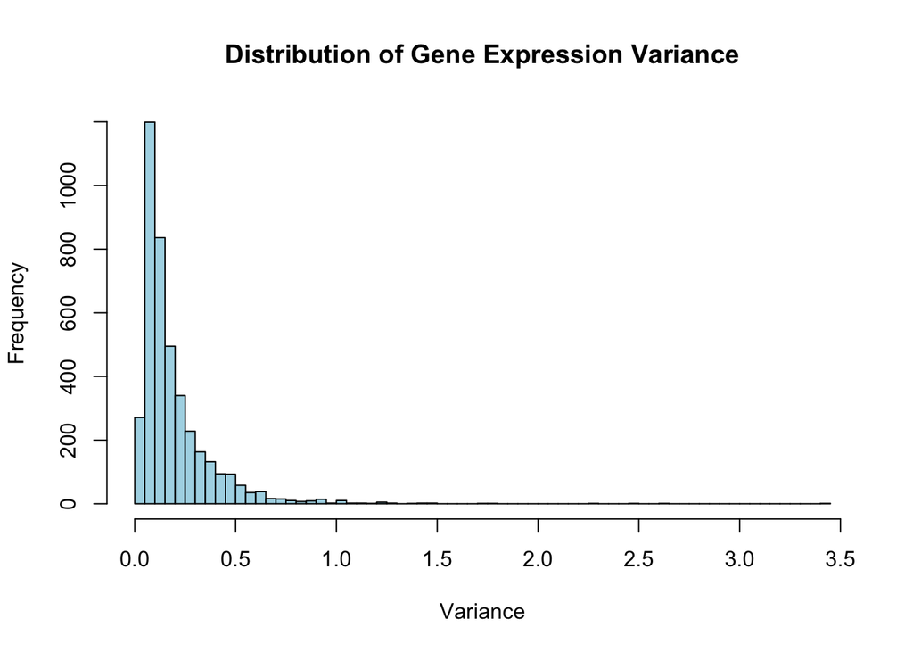

**Why aren’t we scared about this result?**

A typical situation in high dimensional genomic datasets is to have lot of low-correlated variables.This suggests that low-variance genes could be filtered out prior to modeling, as they are unlikely to be informative predictors.

### 2.1.1 Preprocessing

We do not need to scale or standardize the data because the function we will use does it automatically.

Now, we reduce the dimensionality of the dataset through two critical steps:

- removing low variance columns: genes that exhibit near-zero variance across samples provide very little useful information. By removing these variables (in this case, the bottom 10% with the lowest variance), we reduce noise.
- removing columns highly correlated: variables that are highly correlated with each other (coefficient $> 0.90$) add redundant information. We use a function that identifies and removes the variable with the highest mean correlation in every redundant pair.

#### 2.1.1.1 Step 1: Low Variance Filtering

```r
library(caret)

# Compute variance for each predictor (gene)
gene_vars <- apply(X, 2, var)

# We remove the bottom 10% of genes with the lowest variability
threshold_var <- quantile(gene_vars, probs = 0.10)

# Output the actual variance value:
cat("Variance Threshold (10th quantile value):", round(threshold_var, 5), "\n")

# Apply the filter
keep_var_idx <- which(gene_vars > threshold_var)
X_var_filtered <- X[, keep_var_idx]

cat("Dimensions after variance filtering:", dim(X_var_filtered)[1], "x", dim(X_var_filtered)[2] , "\n")
```

```
## Variance Threshold (10th quantile value): 0.05585
## Dimensions after variance filtering: 71 x 3679
```

#### 2.1.1.2 Step 2: Multicollinearity removal

```r
# Compute correlation matrix on the filtered dataset
cor_matrix <- cor(X_var_filtered)

# Identify variables to remove
high_cor_idx <- findCorrelation(cor_matrix, cutoff = 0.90)

# Apply the filter to create the final dataset
if(length(high_cor_idx) > 0) {
  X_final <- X_var_filtered[, -high_cor_idx]
} else {
  X_final <- X_var_filtered
}
```

```
## Original features (p): 4088
## Features removed: 1085
## Final features (p_new): 3003
```

## 2.2 Naïve Two-Step Procedure

The naive two step procedure is a method that combines **LASSO** for variable selection with **OLS** for inference.

Naïve Two-Step Procedure

1. The first step consists in using the LASSO regression with the objective of selecting the candidate variables. This fits a linear model and adds a penalty term to encourage sparsity.

$$\hat{\beta}^{\text{LASSO}} = \arg\min_{\beta} \left( \|y - X\beta\|_2^2
+ \lambda \sum_{j=1}^{p} |\beta_j| \right)$$
where:

- $\lambda>0$ is the **tuning parameter** controlling how many coefficients are set to zero.
- $|\beta_{j}|$ is the absolute value of the coefficient for variable j.

After fitting the LASSO many coefficients will be set to zero. We can now define an active set, composed by all the variable “selected” by LASSO. We should be aware of the fact that LASSO “filters out” irrelevant variables. Only variables in $\widehat M$ are worth keeping for further analysis.

$\widehat M= \{j \in \{1, \dots,p\}:\hat \beta_{j}^{LASSO} \neq 0\}$

2. The second task is to fit OLS on the selected variables. We can perform the regression on $\widehat M$. This operation will output new $\beta_j$ as well as p-value to test whether: $H_j: \beta_j=0$. This means that the OLS refit corrects the bias introduced by LASSO’s shrinkage and lets us evaluate which of the selected variables are statistically significant.

Finally we can define the final set of variable used as: $\widehat S=\{ j \in \widehat M:p_j \leq \alpha \}$, where $\alpha$ is a significance level. Be aware that not all variables selected by LASSO may be truly important. This step filters out variables that are not statistically significant in the refitted model.

We can now perform the naive two-step procedures on our *Riboflavin* dataset. The first step is **LASSO selection**:

```r
library(glmnet)
set.seed(123)
alpha <- 0.05 #usual value
cv.fit     <- cv.glmnet(X, y) # Default: k=10 CV
lambda_opt <- cv.fit$lambda.1se
coefs      <- coef(cv.fit, s = lambda_opt)
```

The first function performs the cross-validated LASSO. It divides the dataset into 10 different folds. For each fold, it computes the LASSO solution on the other 9 folds using a sequence of possible $\lambda$ values and computes the prediction error on the left-out fold. Finally, it computes the average prediction error (MSE) across all folds for each $\lambda$ value to identify the optimal parameter.

- **lambda_opt** selects the best $\lambda$ to use for LASSO regression. If $\lambda$ is small there is the risk of overfitting, larger $\lambda$ provide more stability. However if $/lambda$ is too large there is the risk of underfitting. This method always find an optimal balance.
- **coefs** extracts the estimated values, most of them will be zero due to sparsity, the remaining one will belong to the active set.

```r
M_hat_naive <- which(coefs[-1] != 0)
cat("Features selected by LASSO:", length(M_hat_naive), "\n")
```

```
## Features selected by LASSO: 32
```

We can now proceed by estimating the OLS and showing the **selected** genes.

```r
if(length(M_hat_naive) > 0) {

  # Subset design matrix
  X_subset <- X[, M_hat_naive, drop = FALSE]

  # Fit OLS
  fit_ols <- lm(y ~ X_subset)

  # Extract p-values (skip intercept)
  pvals_naive <- summary(fit_ols)$coefficients[-1, 4]

  # Count significant features
  S_hat_naive  <- M_hat_naive[pvals_naive <= alpha]
  signif_count <- length(S_hat_naive)

  cat("Significant genes with Naïve approach (p < 0.05):", signif_count, "\n")

  if (signif_count > 0) {
    cat("\nSelected significant genes:\n")
    print(colnames(X)[S_hat_naive])
  }
}
```

```
## Significant genes with Naïve approach (p < 0.05): 5
##
## Selected significant genes:
## [1] "ARGF_at"   "YEBC_at"   "YHDS_r_at" "YKBA_at"   "YOAB_at"
```

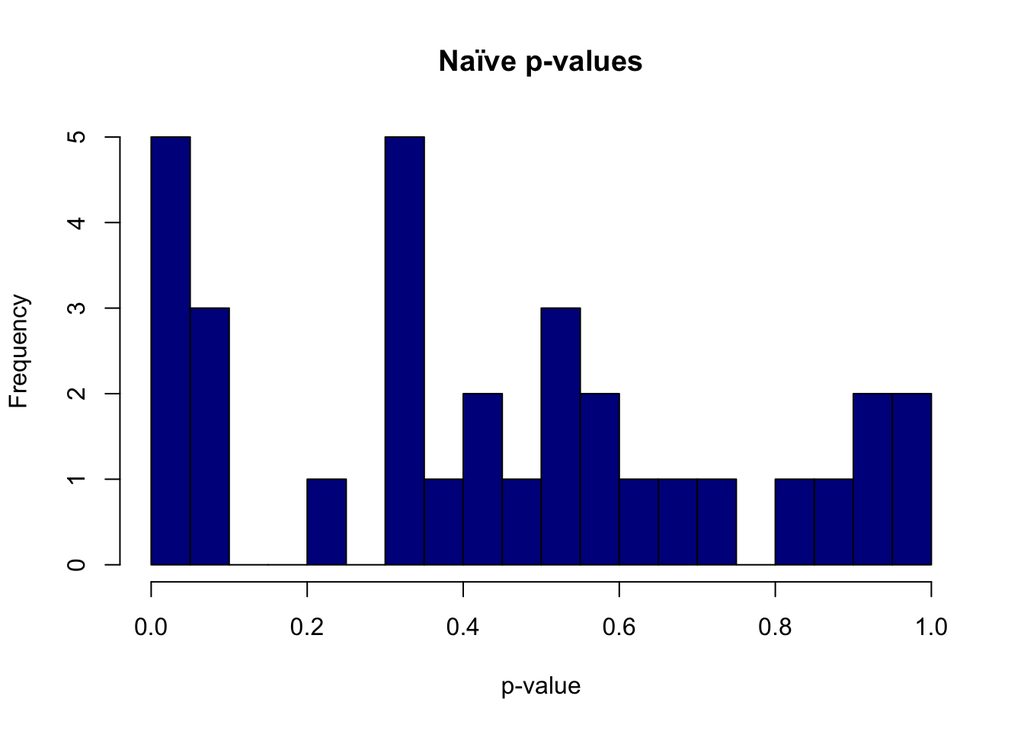

However, a single realization can be misleading, because it highly depends on one specific sample.

```r
B <- 100          # Number of repetitions
p <- ncol(X)      # Total number of features
# Initialize counter vector for all genes
gene_counts <- setNames(rep(0, p), colnames(X))
```

```r
cat("\nStarting stability simulation (B =", B, ")... \n")
set.seed(123)
for(b in 1:B) {

  # 1) LASSO with random CV folds
  cv.fit     <- cv.glmnet(X, y)
  lambda_opt <- cv.fit$lambda.1se

  coefs <- coef(cv.fit, s = lambda_opt)
  M_hat <- which(coefs[-1] != 0)

  # 2) OLS Step
  # Safety checks:
  # - Must select at least 1 variable
  # - Must select fewer variables than observations (n) to compute OLS
  if(length(M_hat) > 0 && length(M_hat) < (nrow(X) - 1)) {

    X_subset <- X[, M_hat, drop = FALSE]
    fit_ols  <- lm(y ~ X_subset)

    # Extract p-values
    pvals <- summary(fit_ols)$coefficients[-1, 4]

    # Identify significant indices within the subset
    signif_idx_subset <- which(pvals <= alpha)
     # Extract p-values
    pvals <- summary(fit_ols)$coefficients[-1, 4]

    # Identify significant indices within the subset
    signif_idx_subset <- which(pvals <= alpha)

    if(length(signif_idx_subset) > 0) {
      # Map back to original indices in X
      original_indices <- M_hat[signif_idx_subset]

      # Update counters
      gene_counts[original_indices] <- gene_counts[original_indices] + 1
    }
  }

  # Progress indicator
  if(b %% 20 == 0) cat(b, "/", B, " iterations completed\n")
}
```

LASSO introduces Bias this makes p-values and standard errors difficult to interpret. For this reason we need to proceed with a de-biasing step fitting OLS.

The algorithm will then select only the genes with a p-value lower than $\alpha$, the others are not significative.

The **final set** will be composed by variables that are both choosen by LASSO and statistically significant.

The genes selected by the re-sampling procedures are shown in the following graph.

```r
# Filter only genes selected at least once
found_genes <- gene_counts[gene_counts > 0]
found_genes <- sort(found_genes, decreasing = TRUE)

cat("\nTop 10 most frequent genes (out of 100 runs):\n")
print(head(found_genes, 10))
```

```
##
## Top 10 most frequent genes (out of 100 runs):
##   ARGF_at   YEBC_at   YOAB_at   YCLB_at   YKBA_at YHDS_r_at   XHLB_at YFHE_r_at
##       100       100       100        55        47        46        12        12
##   YBFI_at   DNAJ_at
##        10         7
```

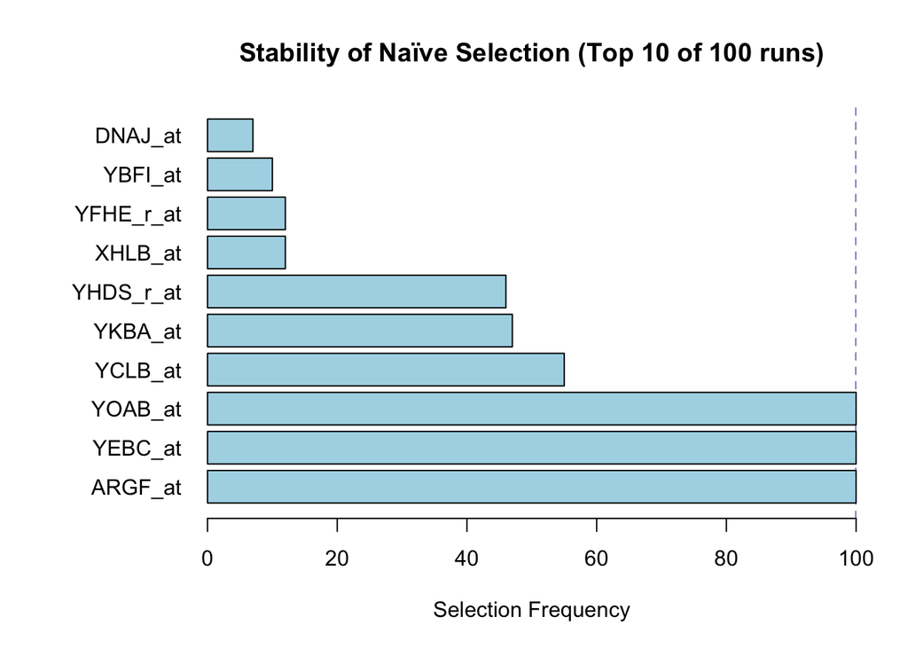

It is fundamental to determine if at least one of the genes selected in a single repetition is also identified by the bootstrap method.

```
## [1] "The genes chosen from both the procedures are:"
```

```
## [1] "ARGF_at"   "YEBC_at"   "YOAB_at"   "YKBA_at"   "YHDS_r_at"
```

All genes selected in the single repetition procedure were also selected by the bootstrap method. This was expected, as the naive approach uses the same data for both steps, introducing **data leakage**.

This procedure presents two **main issues**:

- **Invalid statistical inference**: the process of reusing the data, where the **same dataset** is used first for selecting the best genes and then to test the significance of those features is against the classical statistical assumptions. The p-values and the confidence intervals are computed under the assumptions that the variables were selected independently from test set. This inflates the Type I error, which leads to a high number of False positive genes, considered as significant when actually they are not.
- **Instability**: this model demonstrate poor model robustness. The final set is highly volatile because the final output is sensitive to changes in the input data. The partition of the folds in cross-validation influences the choosen variables. This reliance on random chance means that the final list of selected genes lacks genuine biological reproducibility and indicates that the model is fitting the characteristics of the specific training partitions rather than detecting stable, underlying biological signals.

## 2.3 Single Data Split Strategy

The **single-split approach** is a method designed to perform valid statistical inference after an initial step of variable selection. It addresses the statistical invalidity caused by reusing the same data for both selection and inference. The intuition is to split the dataset in two independent halves to ensure the data used for final p-value is unbiased by selection process.

Single Data Split Strategy

The process consists in **four** main steps:

The total dataset is divided in two samples I and L, where $I = L = \frac{n}{2}$. The *L*earning portion is used only for seleting the variables, while the *I*nference one is used for calculating p-values and perform hypothesis testing.

1. Variables selection through LASSO is applied only to L-set to create the $\widehat M$ sample as: $\widehat M_L \subseteq \{1, \dots, p\}$.
2. The I-set is used only to test the variables selected in the previous step. Once the linear regression is computed, a p-value is produced for each variable $j\in \widehat M$, testing the null hypothesis: $H_0:\beta_j=0$

The final set of p-values is defined as:
$$p_j = \begin{cases}
p_j^I & \text{if } j \in \widehat{M}_L\\
1 & \text{if } j \notin\widehat{M}_L\
\end{cases}$$
**Why do we assign 1 to the not selected p-values?** Because 1 is the largest value that a p-value can have so the related variable will never be considered significative.

3. Due to the fact that multiple tests are performed, p-values must be adjusted to control the family-wise error rate (FWER). The Bonferroni is one of the possible corrections.

$$\tilde{p}_j = \min \left\{ |\widehat{M}_L| \cdot p_j \ , 1 \right\},
\quad j = 1, \dots, p$$
The p-value of the not selected variables will remain 1.

4. The final set is:
   $$\tilde{S} = \left\{ j \in \widehat{M}_L : \tilde{p}_j \leq \alpha
   \right\}$$

It consists in those variables that not only were selected by LASSO but are also statistically significant.

We can try it on the Riboflavin dataset.

Firstly we set the reproducibility criteria and divide the datset in two halves.

```r
set.seed(1312)  # Ensure reproducibility
n_half <- floor(n/2) #35
vec_balanced <- c(rep(0, n_half), rep(1, n - n_half))
# L: Index for the Selection Set (Training)
# I: Index for the Inference Set (Testing)
L <- as.logical(sample(vec_balanced))
I <- !L
paste(sum(L==T), "observation are assigned to L and", sum(L==F), "observation are assigned to I")

# Alpha
alpha <- 0.05

fit_L <- cv.glmnet(X[L, ], y[L])

# Extract indices of non-zero coefficients (using lambda.1se for parsimony)
M_hat <- which(coef(fit_L, s = fit_L$lambda.1se)[-1] != 0)

cat("Number of features selected by LASSO:", length(M_hat), "\n")
```

```
## [1] "36 observation are assigned to L and 35 observation are assigned to I"
## Number of features selected by LASSO: 9
```

Having used the first portion of data only to select relevant variables, we can now use the I set to compute valid p-values for the chosen genes.

```r
# Fit a standard Linear Model on Set I using ONLY features selected in Step 2
fit_I <- lm(y[I] ~ X[I, M_hat])

# Initialize p-value vector with 1s
pval_I <- rep(1, p)

# Extract raw p-values for the selected features
pval_I[M_hat] <- summary(fit_I)$coefficients[-1, 4]

# Count significant features before correction
S_hat <- M_hat[pval_I[M_hat] <= alpha]
cat("Significant features before adjustment (Raw p < 0.05):", length(S_hat), "\n")
```

```
## Significant features before adjustment (Raw p < 0.05): 2
```

We can now apply different testing correction on the variables $\in \widehat M$.

The **Bonferroni correction** is the simplest and most conservative method for controlling (FWER), which is the probability of making at least a Type I error. This method achieves FWER control by simply multiplying each raw p-value by the total number of tests $| \widehat{M}_L|$.

$$\tilde{p}_{j}^{\text{Bonf}} = \min
\left\{ | \widehat{M}_L| \cdot p_j^I, 1 \right\}$$

```r
# A. Bonferroni Correction (FWER control - Conservative)
pval_tilde_Bonf <- rep(1, p)
pval_tilde_Bonf[M_hat] <- p.adjust(pval_I[M_hat], method = "bonferroni")
S_tilde_Bonf <- M_hat[pval_tilde_Bonf[M_hat] <= alpha]

# Print correction results
cat("Significant features after Bonferroni:", length(S_tilde_Bonf), "\n")
```

```
## Significant features after Bonferroni: 1
```

To summarize the selected variables are:

```
##  Index      Name   p_Raw p_Adj_Bonf Significance
##   4004   YXLE_at 0.00069    0.00620            *
##   1516   YCKE_at 0.01068    0.09616
##    624   LYSC_at 0.36120    1.00000
##    825 PHRI_r_at 0.14493    1.00000
##    827   PKSA_at 0.94452    1.00000
##   1279   XHLB_at 0.26230    1.00000
##   1312   XTRA_at 0.91237    1.00000
##   1503   YCGO_at 0.97361    1.00000
##   1827 YFHE_r_at 0.78127    1.00000
```

### 2.3.1 P-value lottery

P-value lottery

The **p-value lottery** refers to the inherent instability of feature selection, where results often depend on ‘luck’ (the specific random split) rather than the true signal.

To show this, we repeat the single-split procedure B times.

We decided to perform this process on 50 repetitions.

```r
B <- 50                       # Number of random splits (iterations)
pval_matrix <- matrix(1, nrow = B, ncol = p)      # Matrix for raw p-values
pval_matrix_adj <- matrix(1, nrow = B, ncol = p)  # Matrix for adjusted p-values

set.seed(123) # Reproducibility
for (i in 1:B) {

  # A. Random Balanced Split
  n_half <- floor(n / 2)
  vec_balanced <- c(rep(0, n_half), rep(1, n - n_half))
  L <- as.logical(sample(vec_balanced)) # Training set (Selection)
  I <- !L                               # Inference set (Testing)

  # B. Variable Selection (LASSO on Set L)
  fit_lasso <- cv.glmnet(X[L, ], y[L])

  # Identify non-zero coefficients (excluding intercept)
  M_hat <- which(coef(fit_lasso, s = fit_lasso$lambda.1se)[-1] != 0)

  # Skip iteration if LASSO selects no variables (safety check)
  if(length(M_hat) == 0) next

  # C. Statistical Inference (OLS on Set I)
  # We refit the model on the test set using only the selected features
  fit_ols <- lm(y[I] ~ X[I, M_hat])

  # D. Store Raw p-values
  current_pvals <- summary(fit_ols)$coefficients[-1, 4]
  pval_matrix[i, M_hat] <- current_pvals

  # E. Store Adjusted p-values (Bonf Correction)
  # We adjust only for the number of variables selected in this split
  pval_matrix_adj[i, M_hat] <- p.adjust(current_pvals, method = "bonf")
}
```

By examining the distribution of p-values for specific genes across many random partitions, we can assess if a signal is robust or merely a result of random chance.

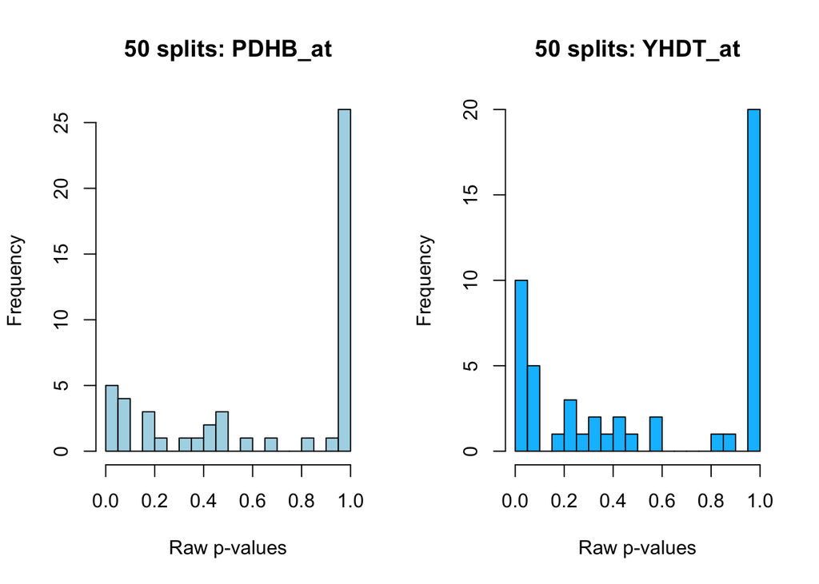

The p-value histograms visually confirm the high **selection instability** inherent in the single-split methodology.

The wide distribution of p-values demonstrates that a variable’s apparent statistical significance is heavily *dependent* on the specific random data split, compromising the *robustness* of the final findings.

## 2.4 Multi-split Strategy

Multi-split Strategy

The **multi-split** procedure is a powerful extension of single-split procedure. It is designed to overcome the *instability* and *volatility* associated with relying on just one random data partition, while still providing statistically valid inference.

The method works by running the entire single-split selection-and-testing procedure a large number of times and then aggregating the results to derive a robust final p-value for each feature.

This procedure develops in **three** main stages:

1. *Repetition* of single split for B times, where B is usually equal to 50 or 100.
2. *Aggregation*. Instead of declaring a feature significant if it passes a threshold in any single split, the multi-split approach aggregates the $B$ p-values (${p}_j^b$) for each feature $j$ into a single, robust $\bar{p}_j$. The aggregation uses a certain quantile $\gamma$ of the p-values across all $B$ splits, divided by $\gamma$ factor:
   $$\bar{p}_j = \frac{1}{\gamma} \cdot
   \text{quantile}_{\gamma} \left( {p}_j^1, \dots, {p}_j^B \right), \quad
   j=1,\dots,p$$
3. *Feature selection*.A feature $j$ is declared significant if its aggregated p-value $\bar{p}_j$ is less than or equal to the desired significance level $\alpha$:
   $$\hat{S} = \{j \in \{1,\dots,p\}: \bar{p}_j \leq
   \alpha\}$$
   The resulting set $\hat{S}$ contains features that consistently showed a strong signal across the multiple independent splits, giving high confidence in their robustness and significance.

In this section, we assess the robustness of the selected features by testing a grid of parameters. The goal is to identify genes that remain significant regardless of the specific tuning of the aggregation method.

We define the search space for our stability analysis:

- ($\gamma$): the mixing parameter used to aggregate p-values across splits (ranging from 0.05 to 0.50).
- ($\alpha$): the significance level for Family-Wise Error Rate (FWER) control.
- $B$: The number of random sample splits (set to 50 to balance stability and computation time).

```r
library(hdi)

# Parameter grid
gamma_vals <- seq(0.05, 0.50, by = 0.05)
alpha_vals <- c(0.05, 0.10, 0.15)

# Number of random sample splits
B <- 50

# Initialize storage
results_df <- data.frame(
  Alpha = numeric(),
  Gamma = numeric(),
  N_Significant = integer(),
  Selected_Genes = character(),
  Selected_P_Values = character(),
  stringsAsFactors = FALSE
)
```

Inside the inner loop, we apply different $\alpha$ thresholds to the same fitted model to check which genes survive the FWER control.

```r
for (g in gamma_vals) {

  cat(paste(">> Processing Gamma =", g, "...\n"))

  # Multi-Split method for the current Gamma
  set.seed(123)
  fit_loop <- multi.split(x = X_final, y = y,
                          B = B,
                          fraction = 0.5,
                          model.selector = lasso.cv,
                          ci = FALSE,
                          gamma = g)

  # Inner Loop
  for (a in alpha_vals) {

    # Identify genes with corrected p-value <= current Alpha
    signif_idx <- which(fit_loop$pval.corr <= a)

    # Count significant features
    count <- length(signif_idx)

    # Extract Gene Names and P-values for reporting
    if (count > 0) {

      gene_names <- paste(colnames(X_final)[signif_idx], collapse = ", ")
      raw_pvals <- fit_loop$pval.corr[signif_idx]
      p_val_str <- paste(format(raw_pvals, digits = 5), collapse = ", ")

    } else {

      gene_names <- "None"
      p_val_str <- "N/A"

    }

    # Append results
    results_df <- rbind(results_df, data.frame(
      Alpha = a,
      Gamma = g,
      N_Significant = count,
      Selected_Genes = gene_names,
      Selected_P_Values = p_val_str
    ))
  }
}
```

Finally, we sort and display the results.

*Multi-Split Stability Analysis*

| Gamma | Significant genes | Selected genes | P-Values |
| --- | --- | --- | --- |
| 0.05 |  |  |  |
| 0.05 | 2 | YCKE_at, YXLD_at | 0.048619, 0.012805 |
| 0.10 | 1 | YXLD_at | 0.00869 |
| 0.15 | 1 | YXLD_at | 0.016229 |
| 0.1 |  |  |  |
| 0.05 | 2 | YCKE_at, YXLD_at | 0.048619, 0.012805 |
| 0.10 | 2 | YCKE_at, YXLD_at | 0.078389, 0.008690 |
| 0.15 | 1 | YXLD_at | 0.016229 |
| 0.20 | 1 | YXLD_at | 0.054566 |
| 0.25 | 1 | YXLD_at | 0.07321 |
| 0.30 | 1 | YXLD_at | 0.096971 |
| 0.35 | 1 | YXLD_at | 0.091533 |
| 0.15 |  |  |  |
| 0.05 | 2 | YCKE_at, YXLD_at | 0.048619, 0.012805 |
| 0.10 | 2 | YCKE_at, YXLD_at | 0.078389, 0.008690 |
| 0.15 | 1 | YXLD_at | 0.016229 |
| 0.20 | 1 | YXLD_at | 0.054566 |
| 0.25 | 1 | YXLD_at | 0.07321 |
| 0.30 | 1 | YXLD_at | 0.096971 |
| 0.35 | 1 | YXLD_at | 0.091533 |
| 0.40 | 1 | YXLD_at | 0.10248 |
| 0.45 | 1 | YXLD_at | 0.12065 |

Multi-split Considerations

The results obtained from the grid search highlight **two critical aspects** regarding the reliability of the selected features:

- **Consistency**: the Multi-Split method demonstrates superior robustness compared to a standard single-split approach. In a single data partition, the selection of significant genes is often subject to a *p-value lottery*. By aggregating p-values over $B=50$ random splits, this method smoothes out sampling noise. The genes identified in this analysis are not artifacts of a lucky split but are consistently significant across multiple perturbations of the dataset, providing strong evidence for their biological relevance.
- **The $\alpha$-$\gamma$ Trade-off**: the interaction between the significance level ($\alpha$) and the aggregation parameter ($\gamma$) illustrates the balance between Type I and Type II error control.  
  Low $\gamma$ (e.g., 0.05) heavily weighs the minimum p-values across splits, on the other hand high $\gamma$ (e.g., 0.50) relies on the median p-value, requiring the gene to be significant in at least half the splits to be detected.

Relaxing $\alpha$ (e.g., to 0.15) retains **stable candidates** even at high $\gamma$ levels. While strict control ($\alpha=0.05$) limits false positives, a permissive threshold reveals signals that are consistently significant across splits, prioritizing average stability over extreme minimum p-values.

# 3 Second example: Ames Housing

The *Ames Housing dataset* describes the sale of residential properties. It contains 79 explanatory variables used to predict the target variable `Sale_Price`. This dataset is particularly suitable for our analysis because the One-Hot Encoding of its many categorical features **drastically increases** the number of predictors, creating the perfect high-dimensional setting to test Variable Selection algorithms.

## 3.1 Data Acquisition and Setup

We load the dataset and simulate a high-dimensional scenario by subsampling only $n=280$ observations.

```r
# Data acquisition

library(AmesHousing)
library(tidyverse)

ames <- make_ames()

set.seed(654)
ames_small <- ames %>% sample_n(280)
paste("Dataset dimensions:", dim(ames_small)[1],"x", dim(ames_small)[2] )
paste("Missing values:",sum(is.na(ames_small)))
```

```
## [1] "Dataset dimensions: 280 x 81"
## [1] "Missing values: 0"
```

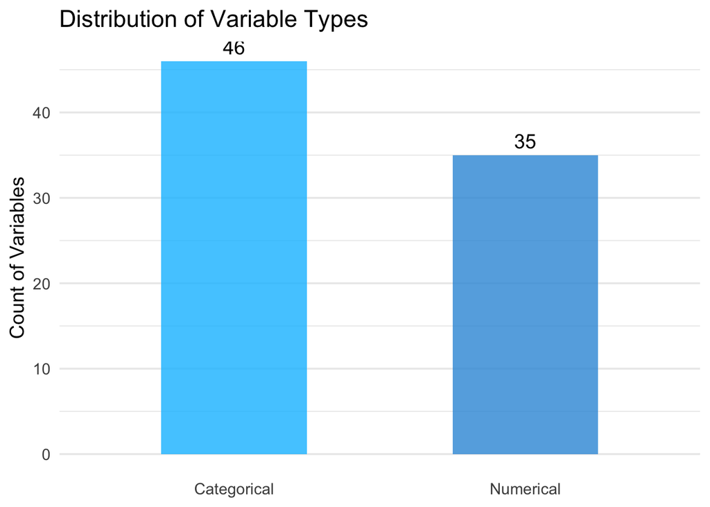

The original dataset contains many categorical variables, which we will later transform into **dummy variables**, increasing $p$ significantly.

### 3.1.1 Creating the Design Matrix

**From Low to High Dimensions: The Effect of One-Hot Encoding**

Transforming categorical variables into dummy variables drastically increases the number of predictors $p$.

This process often shifts the problem into a **High-Dimensional setting** ($p > n$), presenting the following challenge:

- **Mathematical Failure of OLS:** When $p > n$, the design matrix $X^TX$ becomes singular. Standard OLS cannot find a unique solution.

This structural change justifies the use of **Penalized Regression**. LASSO is particularly well-suited for this scenario because it exploits the **sparsity** of the dummy matrix to perform variable selection, effectively discarding irrelevant categories.

```r
# Creation of dummy variables for categorical variables

data <- model.matrix(Sale_Price ~ . - 1, data = ames_small)
y <- ames_small$Sale_Price

paste("Design Matrix dimensions:", dim(data)[1],"x", dim(data)[2] )
paste("Missing values:",sum(is.na(data)))
```

```
## [1] "Design Matrix dimensions: 280 x 309"
## [1] "Missing values: 0"
```

## 3.2 Train-Test Split

We perform an 80-20 split to create a training set for model selection and a test set for final evaluation.

```r
# Data splitting

N <- nrow(data)

set.seed(654)
train_index <- sample(1:N, size = 0.8 * N)

X_train <- data[train_index,]
X_test <- data[-train_index,]

y_train <- y[train_index]
y_test <- y[-train_index]

paste("Training set size: ", dim(X_train)[1])
paste("Test set size: ", dim(X_test)[1])
```

```
## [1] "Training set size:  224"
## [1] "Test set size:  56"
```

## 3.3 Preprocessing

**Standardization** is crucial for penalized regression methods like LASSO. If variables are not on the same scale, the penalty term $\lambda$ will unfairly punish variables with larger scales.

### 3.3.1 Filtering Zero Variance

**Preprocessing Note: Dealing with Zero-Variance Predictors**

Before standardization, we must remove variables with **zero variance**. This is a critical step for two reasons:

1. **Mathematical Stability:** Standardization involves dividing by the standard deviation ($x / \sigma$). If a variable is constant, $\sigma = 0$, it leads to division-by-zero errors (`NaN`) that crash the algorithms.
2. **Categorical Interpretation:** Since our predictors are mostly dummy variables derived from categories, a zero-variance column often represents a **category level that is absent** in the training sample (e.g., a rare neighborhood that was not selected in the 80% split).
   - **Impact on Interpretability:** By removing these columns, we accept that the model cannot learn a specific coefficient for these missing levels. In the final model, any observation belonging to these “removed” categories will implicitly be treated as part of the **baseline reference group** (the intercept), which is the correct behavior for unseen categories.

```r
## We remove the columns with zero variance
cols_variance_ok <- apply(X_train, 2, sd) > 0

X_train_clean <- X_train[, cols_variance_ok]
X_test_clean  <- X_test[, cols_variance_ok]

paste("Columns removed for null variance:", ncol(X_train) - ncol(X_train_clean))
paste("Training design matrix dimensions: ", dim(X_train_clean)[1], "x", dim(X_train_clean)[2] )
```

```
## [1] "Columns removed for null variance: 66"
## [1] "Training design matrix dimensions:  224 x 243"
```

### 3.3.2 Standardization

We apply standardization using the **population variance** formula ($\frac{1}{n}$) for consistency. Crucially, we compute the mean and standard deviation **only on the training set** and apply these parameters to the test set to avoid data leakage.

```r
## We compute the metrics for the standardization on the training
n_train <- nrow(X_train_clean)

train_center <- colMeans(X_train_clean)

train_scale <- sqrt(diag(var(X_train_clean) * ((n_train - 1) / n_train)))

## We apply the metrics to the train
X_train_std <- scale(X_train_clean, center = train_center, scale = train_scale)

## We apply the metrics computed on the training data to the test one
X_test_std <- scale(X_test_clean, center = train_center, scale = train_scale)


X_train <- X_train_std
X_test  <- X_test_std


paste("Mean of the first variable:",round(mean(X_train[,1]),2))
paste("Standard deviation of the first variable:",round(sd(X_train[,1]),2))
```

```
## [1] "Mean of the first variable: 0"
## [1] "Standard deviation of the first variable: 1"
```

```r
ytrain_center <- mean(y_train)

ytrain_scale <- sqrt((var(y_train) * ((n_train - 1) / n_train)))

y_train_std <- scale(y_train, center = ytrain_center, scale = ytrain_scale)

## We apply the metrics computed on the training data to the test one
y_test_std <- scale(y_test, center = ytrain_center, scale = ytrain_scale)


y_train <- y_train_std
y_test  <- y_test_std


paste("Mean of y:",round(mean(y_train),2))
paste("Standard deviation of y:",round(sd(y_train),2))
```

```
## [1] "Mean of y: 0"
## [1] "Standard deviation of y: 1"
```

## 3.4 The Multi-Split Algorithm

This is the core procedure.

**The Necessity of Multi-Split: Handling Selection Bias**

Standard LASSO is excellent for selecting variables, but it does not inherently provide valid p-values for inference. A naive approach—running OLS only on the variables selected by LASSO using the same dataset violates statistical principles, leading to **Selection Bias** (p-values will be artificially too small).

To solve this, we must split the data: one part for selection ($L$), one for inference ($I$). However, a single random split is unstable and “noisy.” The **Multi-Split method** repeats this process $B$ times, aggregating the p-values to ensure that the selected variables are statistically significant and robust to random sampling variations, effectively controlling the Type I error rate in high-dimensional settings.

We repeat the following process $B=100$ times:

1. **Split** the training data randomly into two halves: Selection ($L$) and Inference ($I$).
2. **Select variables** using LASSO on $L$.
3. Compute **p-values using OLS** on $I$, using only the variables selected in the previous step.

This ensures that the inference is performed on **data independent** of the selection process.

```r
library(glmnet)

B <- 100
n <- nrow(X_train)
p <- ncol(X_train)

pval_mat <- matrix(1, nrow=B, ncol=p)
sel_mat  <- matrix(0, nrow=B, ncol=p)


colnames(pval_mat) <- colnames(X_train)
colnames(sel_mat)  <- colnames(X_train)
```

```r
set.seed(654)
for (b in 1:B) {

  #1. Random half-split
  idx <- sample(n)
  L_idx <- idx[1:floor(n/2)]       # Selection Set
  I_idx <- idx[(floor(n/2)+1):n]   # Inference Set

  X_L <- X_train[L_idx, , drop=FALSE]
  y_L <- y_train[L_idx]

  X_I <- X_train[I_idx, , drop=FALSE]
  y_I <- y_train[I_idx]


  #2. LASSO on L set
  cv <- cv.glmnet(x = X_L, y = y_L, family = "gaussian", alpha = 1, nfolds = 5,
                  intercept = FALSE, standardize = FALSE)

  # Coefficients extracted with lambda 1 standard error rule
  beta <- coef(cv, s = "lambda.1se")

  # Selected variables excluding the intercept
  sel_idx <- which(as.numeric(beta[-1, ]) != 0)

  if (length(sel_idx) == 0) next

  sel_mat[b, sel_idx] <- 1

  #3. Linear Model on I set using the variables selected by LASSO
  subset_X_I <- X_I[, sel_idx, drop=FALSE]
  df_I <- data.frame(y = y_I, subset_X_I)

  fit_lm <- try(lm(y ~ ., data = df_I), silent = TRUE)

  if (inherits(fit_lm, "try-error")) next


  # Extracting P-values
  s <- summary(fit_lm)$coefficients

  if (nrow(s) > 1) {

    kept_names <- rownames(s)[-1]
    pvals <- s[-1, 4]
    col_indices <- match(kept_names, colnames(pval_mat))
    valid_idx <- !is.na(col_indices)

    if(any(valid_idx)){
      pval_mat[b, col_indices[valid_idx]] <- pvals[valid_idx]
    }
  }
}
```

### 3.4.1 Variable Selection Results

**P-Value Aggregation: The Median Rule**

Since we perform $B$ splits, each variable receives $B$ different p-values (defaulting to 1 if not selected). To obtain a single significance score, we apply the aggregation formula proposed by Meinshausen et al. (2009):

$$P_{agg} = \min(1, 2 \cdot
\text{median}(p^{(1)}, ..., p^{(B)}))$$

**Why use this formula?**

1. **Correction:** Under the null hypothesis (pure noise), p-values are uniformly distributed between 0 and 1, so their expected median is **0.5**. Multiplying by 2 corrects this bias, ensuring valid Type I error control.
2. **Robustness:** Unlike the mean, the **median** is robust. Even if a variable is not selected in some splits (resulting in $p=1$), the median focuses on the central tendency of the successful splits, provided the variable is selected frequently enough (at least 50% of the time).

We select variables where this aggregated p-value is below our significance level $\alpha = 0.20$.

```r
alpha <- 0.20

# Aggregation rule for P-values
bar_p <- apply(pval_mat, 2, function(v) min(2 * median(v, na.rm = TRUE), 1))

# Selection of variables with p-value < alpha
S_hat <- which(bar_p <= alpha)

S_hat_names <- colnames(X_train)[S_hat]

print(paste("Number of selected variables:", length(S_hat)))


  results <- data.frame(
    Variable = S_hat_names,
    Adj_PValue = round(bar_p[S_hat],4)
  )

  print(as.tibble(results[order(results$Adj_PValue), ]))
```

```
## [1] "Number of selected variables: 5"
## # A tibble: 5 × 2
##   Variable              Adj_PValue
##   <chr>                      <dbl>
## 1 Overall_QualExcellent     0
## 2 Gr_Liv_Area               0
## 3 Total_Bsmt_SF             0.0001
## 4 Bsmt_ExposureGd           0.0752
## 5 Garage_Area               0.148
```

**Interpretation of the Selected Variables**

The Multi-Split algorithm identified a concise set of predictors that aligns perfectly with real estate intuition. We can categorize them into two types:

### 3.4.2 Selection Frequency

We can visualize how often each variable was selected by the LASSO step across the 100 iterations. This gives us an idea of the **stability of the selection**.

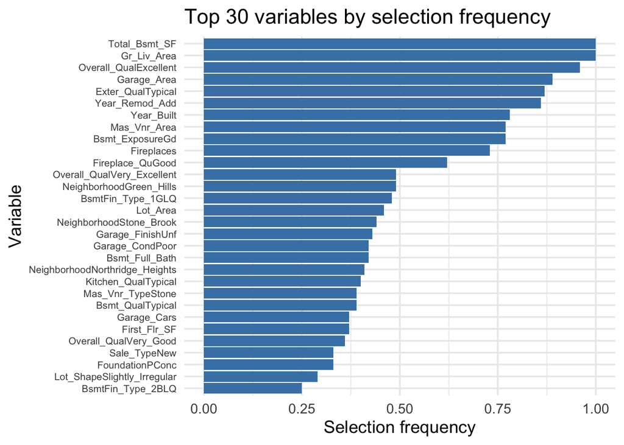

We can also inspect the raw counts and adjusted median p-values for the most relevant variables.

|  | Count | Adj_Pval |
| --- | --- | --- |
| Overall_QualExcellent | 96 | 0.0000 |
| Gr_Liv_Area | 100 | 0.0000 |
| Total_Bsmt_SF | 100 | 0.0001 |
| Bsmt_ExposureGd | 77 | 0.0752 |
| Garage_Area | 89 | 0.1480 |
| Year_Remod_Add | 86 | 0.2222 |
| Year_Built | 78 | 0.2732 |
| Exter_QualTypical | 87 | 0.3804 |
| Fireplaces | 73 | 0.4040 |
| Fireplace_QuGood | 62 | 0.7911 |

[output cut: 10 more lines]

## 3.5 Final Model Evaluation

Now we build the **final predictive model** using only the selected variables. We train an OLS model on the training set and evaluate it on the held-out test set.

```r
# Evaluation

# We retain the selected variables
X_train_selected <- X_train[, S_hat, drop=FALSE]
X_test_selected  <- X_test[, S_hat, drop=FALSE]


train_df_final <- data.frame(y = y_train, X_train_selected)
test_df_final  <- data.frame(X_test_selected)

# Linear model
final_model <- lm(y ~ ., data = train_df_final)


summary(final_model)
```

```
##
## Call:
## lm(formula = y ~ ., data = train_df_final)
##
## Residuals:
##     Min      1Q  Median      3Q     Max
## -1.2024 -0.2265  0.0114  0.2187  1.6882
##
## Coefficients:
##                         Estimate Std. Error t value Pr(>|t|)
## (Intercept)           -2.296e-16  2.532e-02   0.000        1
## Overall_QualExcellent  2.209e-01  2.878e-02   7.677 5.41e-13 ***
## Bsmt_ExposureGd        1.179e-01  2.766e-02   4.265 2.98e-05 ***
## Total_Bsmt_SF          3.268e-01  3.346e-02   9.766  < 2e-16 ***
## Gr_Liv_Area            4.221e-01  2.984e-02  14.149  < 2e-16 ***
## Garage_Area            1.913e-01  3.486e-02   5.487 1.13e-07 ***
## ---
## Signif. codes:  0 '***' 0.001 '**' 0.01 '*' 0.05 '.' 0.1 ' ' 1
##
## Residual standard error: 0.3789 on 218 degrees of freedom
## Multiple R-squared:  0.8603, Adjusted R-squared:  0.8571
## F-statistic: 268.5 on 5 and 218 DF,  p-value: < 2.2e-16
```

```r
# Predictions
predictions <- predict(final_model, newdata = test_df_final)

predictions <- (predictions * ytrain_scale) + ytrain_center
y_test <- (y_test * ytrain_scale) + ytrain_center

# Metrics
mse_val <- mean((y_test - predictions)^2)

rmse_val <- sqrt(mse_val)

mae_val <- mean(abs(y_test - predictions))

rss <- sum((y_test - predictions)^2)  # Residual Sum of Squares
tss <- sum((y_test - mean(y_test))^2) # Total Sum of Squares
r2_val <- 1 - (rss / tss)
```

Metrics evaluated on the **test set**.

```
##  Metric                         Value
##  Mean Squared Error (MSE)       2,850,220,539
##  Root Mean Squared Error (RMSE) $ 53,387
##  Mean Absolute Error (MAE)      $ 35,612
##  R-Squared (R2)                 0.7593
```

The plot below compares the Predicted Price vs. Real Price. Points close to the red dashed line indicate accurate predictions.

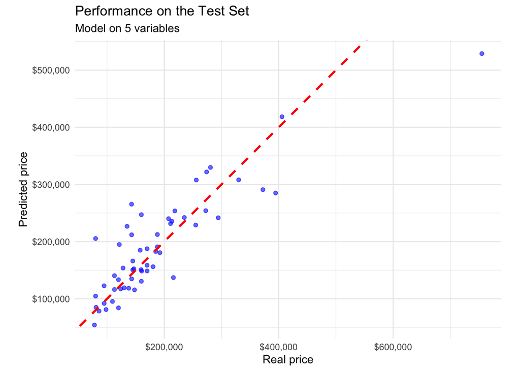

## 3.6 Selected Model vs Full LASSO

Finally, we compare our parsimonious model (built on 5 variables) against a “Full Lasso” model trained on all available variables.

This comparison serves as a benchmark: it validates that our aggressive variable selection has retained the signal’s core information, achieving comparable predictive power while strictly enforcing parsimony.

```r
# --- FINAL MODEL vs FULL LASSO ---

# LASSO
set.seed(654)
cv_full_lasso <- cv.glmnet(X_train, y_train,
                           alpha = 1,
                           family = "gaussian",
                           standardize = FALSE,
                           intercept = FALSE)

# LASSO predictions
pred_full <- predict(cv_full_lasso, newx = X_test, s = "lambda.1se")
pred_full <- as.vector(pred_full)

pred_full <- (pred_full * ytrain_scale) + ytrain_center

# LASSO metrics
rmse_full <- sqrt(mean((y_test - pred_full)^2))
r2_full   <- 1 - (sum((y_test - pred_full)^2) / sum((y_test - mean(y_test))^2))


coef_full <- coef(cv_full_lasso, s = "lambda.1se")
n_vars_full <- sum(coef_full != 0)


comparison_full <- data.frame(
  Model = c("Multi-Split", "Full LASSO"),
  RMSE = c(rmse_val, rmse_full),
  R_Squared = c(r2_val, r2_full),
  Num_Variables = c(length(S_hat), n_vars_full)
)

library(knitr)
library(kableExtra)
kable(comparison_full) %>%
  kable_styling(bootstrap_options = "striped", full_width = F)
```

| Model | RMSE | R_Squared | Num_Variables |
| --- | --- | --- | --- |
| Multi-Split | 53387.46 | 0.7592821 | 5 |
| Full LASSO | 47216.83 | 0.8117116 | 29 |

We visualize the trade-off between complexity and accuracy.

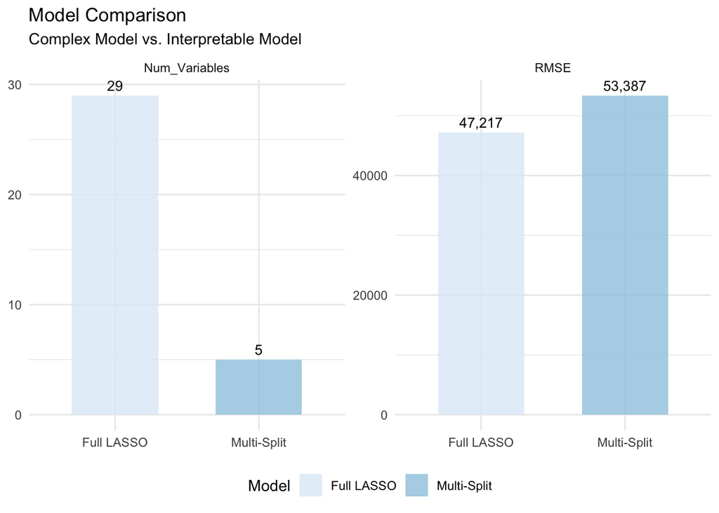

**Benchmark Analysis**

**Complexity**: We achieve this performance using drastically fewer variables, making the model much easier to explain.

## 3.7 Selected Model vs Full Categorical

```r
# --- COMPARISON: SELECTED DUMMIES vs FULL CATEGORICAL ---

# We select the original columns (3 numeric + 2 categorical)
vars_to_keep <- c("Sale_Price", "Overall_Qual", "Bsmt_Exposure",
                  "Total_Bsmt_SF", "Gr_Liv_Area", "Garage_Area")

# Subset original data (Raw)
train_cat_raw <- ames_small[train_index, vars_to_keep]
test_cat_raw  <- ames_small[-train_index, vars_to_keep]

# Standardization
# We must scale numeric vars to be fair, but leave factors as they are
num_vars <- c("Total_Bsmt_SF", "Gr_Liv_Area", "Garage_Area")

# Compute stats on Train
n_train <- nrow(train_cat_raw)
num_center <- colMeans(train_cat_raw[, num_vars])
num_scale  <- sqrt(diag(var(train_cat_raw[, num_vars]) * ((n_train - 1) / n_train)))

# Apply scaling to X
train_cat_raw[, num_vars] <- scale(train_cat_raw[, num_vars], center = num_center, scale = num_scale)
test_cat_raw[, num_vars]  <- scale(test_cat_raw[, num_vars], center = num_center, scale = num_scale)

# Apply scaling to Y (Sale_Price)
y_center <- mean(train_cat_raw$Sale_Price)
y_scale  <- sqrt(var(train_cat_raw$Sale_Price) * ((n_train - 1) / n_train))

train_cat_raw$Sale_Price <- scale(train_cat_raw$Sale_Price, center = y_center, scale = y_scale)

test_cat_y_std <- scale(test_cat_raw$Sale_Price, center = y_center, scale = y_scale)


# Fit Linear Model with Full Categories
# R automatically expands factors into ALL their dummy variables
model_cat <- lm(Sale_Price ~ ., data = train_cat_raw)
summary(model_cat)
```

```
##
## Call:
## lm(formula = Sale_Price ~ ., data = train_cat_raw)
##
## Residuals:
##      Min       1Q   Median       3Q      Max
## -1.15690 -0.18765 -0.00106  0.20182  1.15753
##
## Coefficients:
##                            Estimate Std. Error t value Pr(>|t|)
## (Intercept)                -0.50557    0.24638  -2.052 0.041426 *
## Overall_QualFair            0.30596    0.28809   1.062 0.289465
## Overall_QualBelow_Average   0.23498    0.24587   0.956 0.340327
## Overall_QualAverage         0.30965    0.23823   1.300 0.195119
## Overall_QualAbove_Average   0.42239    0.23983   1.761 0.079667 .
## Overall_QualGood            0.71945    0.24525   2.934 0.003727 **
## Overall_QualVery_Good       0.91699    0.25263   3.630 0.000357 ***
## Overall_QualExcellent       1.77989    0.27092   6.570 3.97e-10 ***
## Overall_QualVery_Excellent  1.51775    0.31964   4.748 3.82e-06 ***
## Bsmt_ExposureGd             0.10132    0.08601   1.178 0.240150
## Bsmt_ExposureMn            -0.27991    0.10241  -2.733 0.006810 **
## Bsmt_ExposureNo            -0.15712    0.06390  -2.459 0.014747 *
## Bsmt_ExposureNo_Basement   -0.01272    0.15461  -0.082 0.934503
## Total_Bsmt_SF               0.26208    0.03756   6.978 3.92e-11 ***
## Gr_Liv_Area                 0.35011    0.02862  12.232  < 2e-16 ***
## Garage_Area                 0.10138    0.03211   3.157 0.001828 **
## ---
## Signif. codes:  0 '***' 0.001 '**' 0.01 '*' 0.05 '.' 0.1 ' ' 1
##
## Residual standard error: 0.3241 on 208 degrees of freedom
## Multiple R-squared:  0.9025, Adjusted R-squared:  0.8954
## F-statistic: 128.3 on 15 and 208 DF,  p-value: < 2.2e-16
```

Impact of Granularity on Model Complexity

| Model | RMSE | R_Squared | Num_Variables |
| --- | --- | --- | --- |
| Multi-Split | 53387.46 | 0.7592821 | 5 |
| Categorical | 46211.96 | 0.8196406 | 15 |

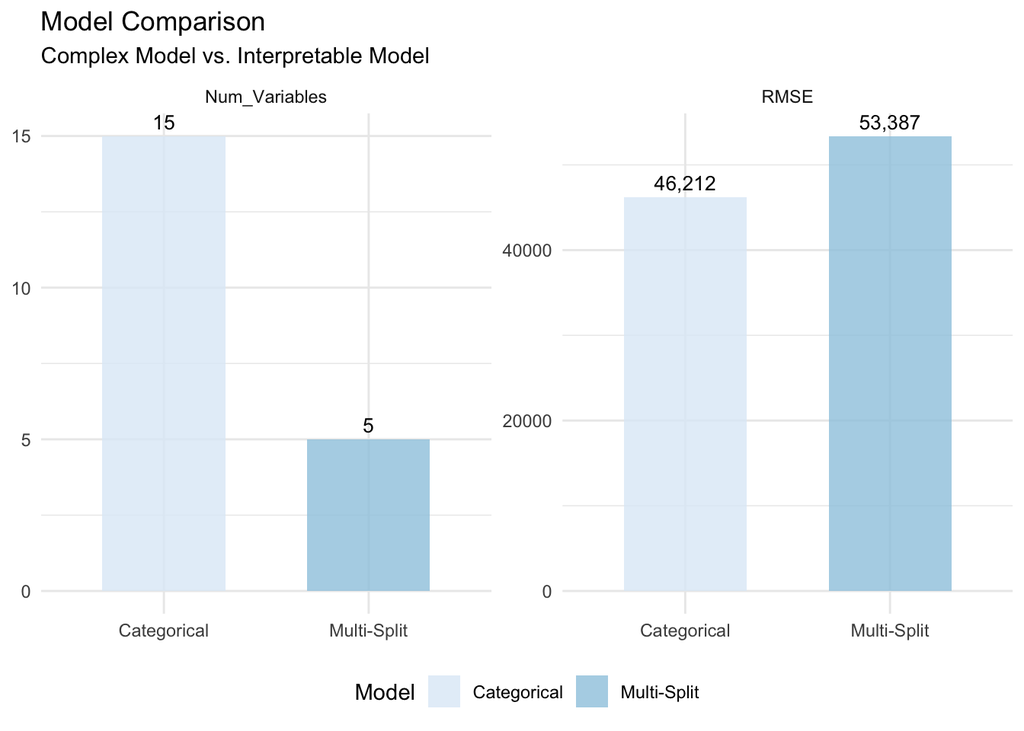

**Interpretability Trade-off: Sparse vs. Granular**

Final Conclusions: The Optimal Trade-off

In conclusion, the Multi-Split method establishes an **optimal trade-off between interpretability and accuracy**.